# Part I - (Dataset Exploration Title)

### What is the structure of your dataset?

The dataset chosen was the Ford GoBike, it has 183412 rows and 16 columns.

### What is/are the main feature(s) of interest in your dataset?

The main points are: Gender, Duration of the pass, type of user, dates of use.

### What features in the dataset do you think will help support your investigation into your feature(s) of interest?

The start and end date fields, gender, user type, year of birth, usage time in seconds.

## Univariate Exploration

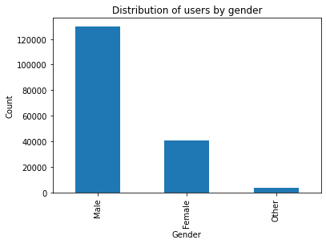

```python
# Distribution of people by gender

base_color = sb.color_palette()[0]
gender = df.member_gender.value_counts()
gender.plot(kind='bar');
plt.xlabel('Gender')
plt.ylabel('Count')
plt.title('Distribution of users by gender');
```

```python
type_counts = df.user_type.value_counts()
```

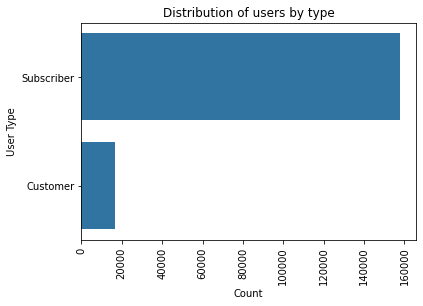

```python
base_color = sb.color_palette()[0]
type_counts = df.user_type.value_counts()
type_order = type_counts.index
sb.countplot(data = df, y= 'user_type', color =base_color, order = type_order);
plt.xticks(rotation = 90);
plt.xlabel('Count')
plt.ylabel('User Type')
plt.title('Distribution of users by type');
```

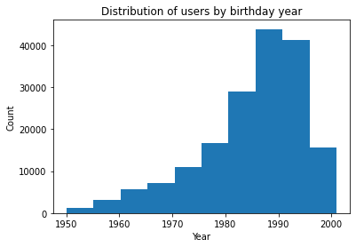

```python
fig = plt.figure()
ax = fig.add_axes([.725, .125, .775, .755])
ax.hist(data=df, x='member_birth_year');
plt.xlabel('Year')
plt.ylabel('Count')
plt.title('Distribution of users by birthday year');
```

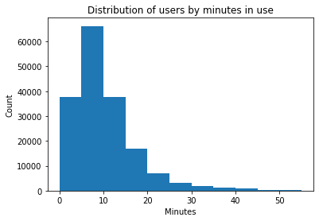

```python
bins = np.arange(0, 60, 5)
plt.hist(data = df, x='duration_min', bins = bins);
plt.xlabel('Minutes')
plt.ylabel('Count')
plt.title('Distribution of users by minutes in use');
```

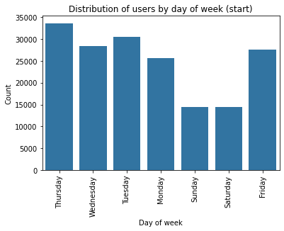

```python
base_color = sb.color_palette()[0]
sb.countplot(data = df, x= 'start_time_dweek', color =base_color);
plt.xticks(rotation = 90)
plt.xlabel('Day of week')
plt.ylabel('Count')
plt.title('Distribution of users by day of week (start)');
```

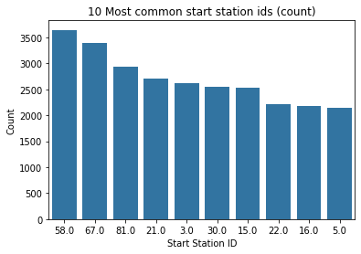

```python
station_start = df.start_station_id.value_counts().iloc[:10]
#df_station = df.loc[df['start_station_id'].isin(station_start.index)]
#df_station.start_station_id.value_counts()
base_color = sb.color_palette()[0]
sb.countplot(data = df_station, x= 'start_station_id', color =base_color, order = station_start.index)
plt.xlabel('Start Station ID')
plt.ylabel('Count')
plt.title('10 Most common start station ids (count)');
```

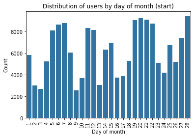

```python
base_color = sb.color_palette()[0]
sb.countplot(data = df, x= 'start_time_day', color =base_color);
plt.xticks(rotation = 90)
plt.xlabel('Day of month')
plt.ylabel('Count')
plt.title('Distribution of users by day of month (start)');
```

### Discuss the distribution(s) of your variable(s) of interest. Were there any unusual points? Did you need to perform any transformations?

For the start_time and end_time variables, there is a need to transform to datetime, in addition to converting the date fields to day of the week, day of the month, conversion from seconds to minutes and hours.

### Of the features you investigated, were there any unusual distributions? Did you perform any operations on the data to tidy, adjust, or change the form of the data? If so, why did you do this?

In this initial work, there was a need to clean the data, there were birth dates in the year 1878 for example, there were also several NaN fields.

## Bivariate Exploration

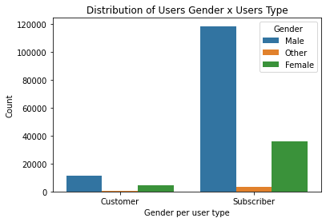

```python
sb.countplot(data = df, x = 'user_type', hue = 'member_gender')
plt.xlabel('Gender per user type')
plt.ylabel('Count')
plt.title('Distribution of Users Gender x Users Type');
plt.legend(title='Gender')
```

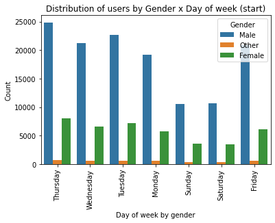

```python
sb.countplot(data = df, x = 'start_time_dweek', hue = 'member_gender')
plt.xticks(rotation = 90)
plt.xlabel('Day of week by gender')
plt.ylabel('Count')
plt.title('Distribution of users by Gender x Day of week (start)');
plt.legend(title='Gender');
```

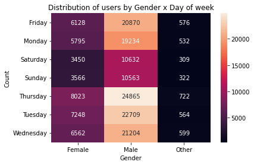

```python
ct_counts = df.groupby(['start_time_dweek', 'member_gender']).size()
ct_counts = ct_counts.reset_index(name='count')
ct_counts = ct_counts.pivot(index = 'start_time_dweek', columns = 'member_gender', values = 'count')
sb.heatmap(ct_counts,annot = True, fmt = 'd')
plt.xlabel('Gender')
plt.ylabel('Count')
plt.title('Distribution of users by Gender x Day of week');
```

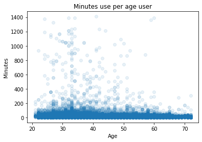

```python
plt.scatter(data = df, x = 'year_birth', y = 'duration_min', alpha=1/10);
plt.xlabel('Age')
plt.ylabel('Minutes')
plt.title('Minutes use per age user');
```

### Talk about some of the relationships you observed in this part of the investigation. How did the feature(s) of interest vary with other features in the dataset?

For this session, we can use as an example the distribution of use by days of the week x gender, where we were able to identify a greater use by the male gender on all days of the week.

### Did you observe any interesting relationships between the other features (not the main feature(s) of interest)?

Another relationship raised was the distribution of users by gender x user type. In this relationship we were able to identify a great advantage for subscriber users.

## Multivariate Exploration

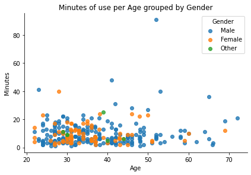

```python
g = sb.FacetGrid( data = df.sample(300), hue = 'member_gender', height = 4, aspect = 1.5 )
g.map(sb.regplot,'year_birth', 'duration_min', x_jitter = 0.04, fit_reg = False);
plt.xlabel('Age')
plt.ylabel('Minutes');
plt.title('Minutes of use per Age grouped by Gender');
plt.legend(title='Gender');
```

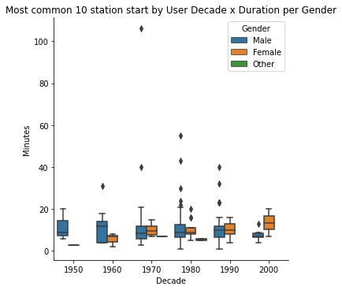

```python
#https://stackoverflow.com/questions/37278654/boxplots-by-group-for-multivariate-two-factorial-designs-using-matplotlib-pand

station_start = df.start_station_id.value_counts().iloc[:10]
df_station = df.loc[df['start_station_id'].isin(station_start.index)]
order = ['1950','1960','1970','1980','1990','2000']
sb.catplot(data=df_station.sample(200), x='decade', y='duration_min',
              hue='member_gender',
             kind='box', legend=False, order = order)
plt.xlabel('Decade')
plt.ylabel('Minutes');
plt.title('Most common 10 station start by User Decade x Duration per Gender');
plt.legend(title='Gender');
```

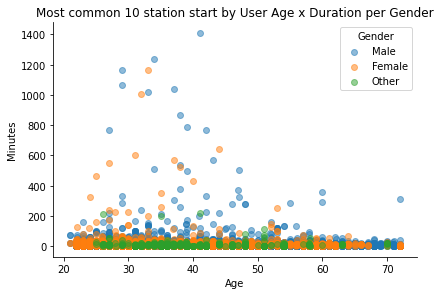

```python
station_start = df.start_station_id.value_counts().iloc[:10]
df_station = df.loc[df['start_station_id'].isin(station_start.index)]
g = sb.FacetGrid( data = df_station, hue = 'member_gender', height = 4, aspect = 1.5 )
g.map(sb.regplot,'year_birth', 'duration_min', x_jitter = 0.04, fit_reg = False,scatter_kws = {'alpha' : 1/2});
plt.xlabel('Age')
plt.ylabel('Minutes');
plt.title('Most common 10 station start by User Age x Duration per Gender');
plt.legend(title='Gender');
```

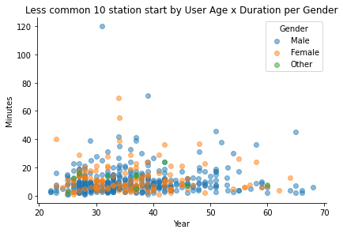

```python
station_start = df.start_station_id.value_counts().iloc[:-10]
df_station = df.loc[df['start_station_id'].isin(station_start.index)]
g = sb.FacetGrid( data = df_station.sample(500), hue = 'member_gender', height = 4, aspect = 1.5 )
g.map(sb.regplot,'year_birth', 'duration_min', x_jitter = 0.04, fit_reg = False,scatter_kws = {'alpha' : 1/2});
plt.xlabel('Year')
plt.ylabel('Minutes');
plt.title('Less common 10 station start by User Age x Duration per Gender');
plt.legend(title='Gender');
```

### Were there any interesting or surprising interactions between features?

Yes, regardless of the relationship between gender, age, time of use, all age groups usually have a duration below 200 minutes.